# Vignette 3: Stitching

# Overview 🔍

This vignette will walk you through the process of stitching together overlapping adjacent FOVs in your MERFISH experiment. Stitching is needed to obtain a coherent coordinate system across all FOVs. It can be done on DAPI images, or on the reference bit in MERFISH (i.e. the image that registration is performed with respect to – typically the first bit). Recall that as part of spotcalling (Chapter 3.3.2) and cell segmentation (Chapter 5.4), reference images are returned as REGIM_{ FOV Name }.png. We will be using the latter images and so stitching will have to be performed after the previous two tasks.

1. **Establish parameters and view FOV coordinate metatadata**🔅:

```r
library(masmr)
library(imager)
library(abind)
library(ggplot2)
library(patchwork)
library(bioimagetools)
library(RBioFormats)
```

```r
data_dir <- "~/JIN_SIM/20190718_WK_T2_a_B2_R8_12_d50/"
out_dir <- "~/OUT"

establishParams(
  imageDirs         =  paste0(data_dir, 'S10/'),
  imageFormat       = ".ome.tif",
  codebookFileName  = paste0(data_dir, "codebook/Jin_codebook_B.tsv"),
  outDir            = out_dir,
  dapiDir           = paste0(data_dir, "DAPI_1/"),
  fpkmFileName      = paste0(data_dir, "FPKM_data/Jin_FPKMData_B.tsv"),
  nProbesFileName   = paste0(data_dir, "ProbesPerGene.csv")
  )
```

```
## Assuming .ome.tif is extension for meta files...
```

```
## resumeMode = TRUE...
```

```
## 100 images across 16 cycles ( 4 ON-bit codes )...
```

```r
establishCleanSlate()
```

```
##  [1] ".Random.seed"      "all_markers"       "bit_number"        "cellExp"           "cellIDs_a"         "cleanSlate"        "clusterInfo"
##  [8] "cxWindow"          "data_dir"          "distanceMetric"    "file"              "filtout"           "forExclusion"      "forReg"
## [15] "gcm"               "gcm_mat"           "gcm_t"             "genePalette"       "hnnDistBins"       "i"                 "im"
## [22] "img1"              "img2"              "imList"            "imMetricName"      "imMetrics"         "imsub"             "maxClusterSize"
## [29] "metric"            "n"                 "nuclei_area"       "out_dir"           "p0"                "p1"                "p2"
## [36] "p3"                "p4"                "params"            "PC_dim"            "percBlank"         "probabilityBLANK"  "q_a1"
## [43] "q_a2"              "series"            "seur_obj"          "seur_obj.markers"  "spotcalldf"        "thresh"            "top5_markers"
## [50] "troubleshootPlots"
```

```r
params$current_fov <- 'MMStack_1-Pos_002_003'

# minimum requirements files for stitching:
list.files( params$parent_out_dir, pattern = 'GLOBALCOORD.csv', recursive = T, full.names = T )
```

```
## [1] "/home/rstudio/OUT/DAPI/GLOBALCOORD.csv"    "/home/rstudio/OUT/IM/GLOBALCOORD.csv"      "/home/rstudio/OUT/OUT/OUT_GLOBALCOORD.csv"
```

```r
list.files( params$parent_out_dir, pattern = 'META_RESOLUTION.txt', recursive = T, full.names = T )
```

```
## [1] "/home/rstudio/OUT/DAPI/META_RESOLUTION.txt" "/home/rstudio/OUT/IM/META_RESOLUTION.txt"
```

2. **Loading an example FOV and its surrounding Stitch images** 🪡:

For stitching, we will need to load a reference FOV, and the FOVs immediately surrounding it. For instance, let’s select the same FOV processed in previous Chapters. From one of the GLOBALCOORD.csv files, we expect to load the four FOVs in blue below, alongside our reference FOV (red).

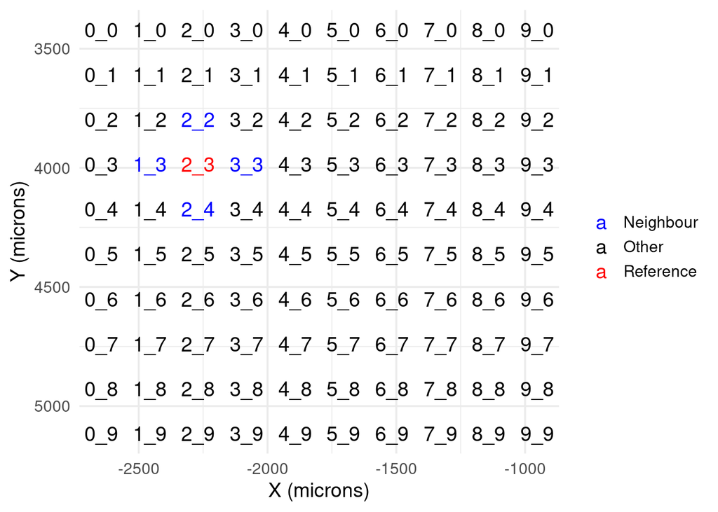

```r
params$current_fov <- 'MMStack_1-Pos_002_003'
gcx <- data.table::fread(
  list.files( params$parent_out_dir, pattern = 'GLOBALCOORD.csv', recursive = T, full.names = T )[1],
  data.table = F
)
gcx <- gcx[!duplicated(gcx$fov),]
gcx$X <- as.integer( factor(gcx$x_microns) )
gcx$Y <- as.integer( factor(gcx$y_microns) )
gcx$CX <- gcx$X + 1i * gcx$Y
gcx$fov_type <- ifelse(
  gcx$fov==params$current_fov, 'Reference',
  ifelse(
    Mod( gcx$CX - gcx$CX[gcx$fov==params$current_fov] ) == 1,
    'Neighbour', 'Other'))
gcx$short_name <- gsub('MMStack_1-Pos_|00', '', gcx$fov)
ggplot( gcx ) +
  geom_text( aes(x=x_microns, y=y_microns, label=short_name, colour = fov_type),
             size = 5 ) +
  scale_colour_manual( name='', values = c('Reference' = 'red', 'Neighbour' = 'blue', 'Other' = 'black')) +
  scale_y_reverse() + xlab('X (microns)') + ylab('Y (microns)') +
  theme_minimal(base_size=14)
```

The actual loading is accomplished with the readImagesForStitch function which reads in your processed files from running registerImages() and saveCellSegMasks().

```r
DapiList <- readImagesForStitch(subDirectory = 'DAPI')
```

```
##
## Processing FOV MMStack_1-Pos_001_003 (1 of 5)...
```

```
##
## Reading images...
```

```
## 1 of 1...
## Processing FOV MMStack_1-Pos_002_002 (2 of 5)...
##
## Reading images...
## 1 of 1...
## Processing FOV MMStack_1-Pos_002_003 (3 of 5)...
##
## Reading images...
## 1 of 1...
## Processing FOV MMStack_1-Pos_002_004 (4 of 5)...
##
## Reading images...
## 1 of 1...
## Processing FOV MMStack_1-Pos_003_003 (5 of 5)...
##
## Reading images...
## 1 of 1...
## Processing images...
```

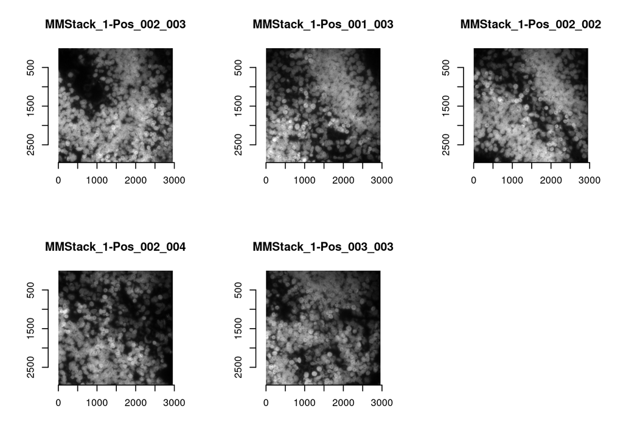

```r
par(mfrow=c(2,3))
for(i in 1:length(DapiList)){
  plot(imager::as.cimg(DapiList[[i]]), main=names(DapiList)[i])
}
```

The task of stitching is similar to image registration and masmr’s stitching algorithm stitchImages similarly relies on cross-correlation to a reference image. As default, the first image in the list – which should also be the current FOV being processed – is used.

```r
stitchResults <- stitchImages(DapiList, returnTroubleShootPlots = TRUE)
```

```
##
## Aligning adjacent FOVs...
```

```
## 1 of 4...2 of 4...3 of 4...4 of 4...Generating QC plots for evaluating stitching...
##
## Generating QC plots for each neighbour in stitching...
## 1 of 4...
## 2 of 4...
## 3 of 4...
## 4 of 4...
```

```r
knitr::kable(stitchResults, format = 'html', booktabs = T)
```

| fov | shift_pixel |
| --- | --- |
| MMStack_1-Pos_001_003 | -2664+25i |
| MMStack_1-Pos_002_002 | -25-2664i |
| MMStack_1-Pos_002_004 | 27+2664i |
| MMStack_1-Pos_003_003 | 2664-27i |

Stitching can be evaluated visually. Below we show how a FOV to the right of our reference FOV aligns prior to and after stitching.

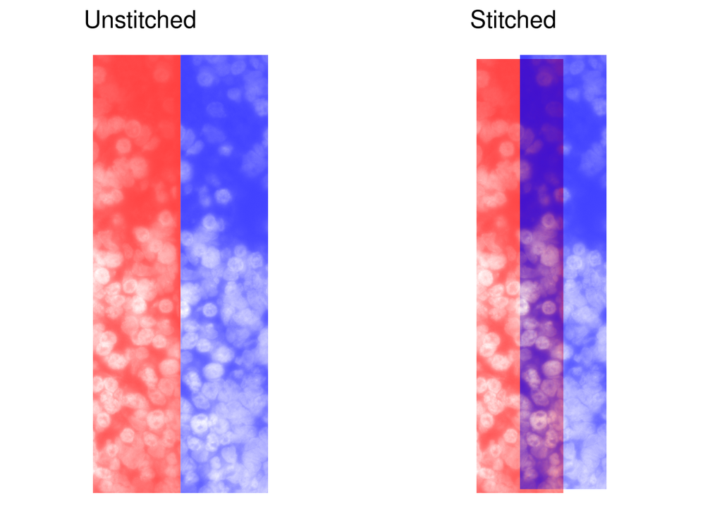

```r
## Plots are returned for each neihgbour, will show just one below
p_unstitched <- troubleshootPlots[['STITCH_EVAL']][[4]][['UNSTITCHED']]
p_stitched <- troubleshootPlots[['STITCH_EVAL']][[4]][['STITCHED']]

## Re-scale alpha so that low brightness is more solid
## We find this makes the stitch visually clearer for DAPI images
cowplot::plot_grid( plotlist = list(
  p_unstitched  + ggtitle('Unstitched') + scale_alpha(range=c(0.75, 0)),
  p_stitched  + ggtitle('Stitched') + scale_alpha(range=c(0.75, 0))
), nrow=1)
```

3. **Perform stitching on all FOVs** 🧵:

```r
## Preparation ahead of looping through FOVs
establishCleanSlate()
params$verbose <- F

## Start loop
for( fovName in params$fov_names ){

  ## Report current FOV / iteration
  message( paste0(
    '\n', fovName, ': ',
    which(params$fov_names==fovName), ' of ',
    length(params$fov_names), '...' ) )

  ## Check if file has been created, skip if yes
  if( params$resumeMode ){
    checkFile <- file.exists( paste0(params$out_dir, 'STITCH/STITCH_', fovName, '.csv') )
    if(checkFile){
      cat('FOV has been processed...Skipping...')
      next
    }
  }

  ## Keep track of the current_fov
  params$current_fov <- fovName


  ## Stitch with respect to DAPI image
  DapiList <- readImagesForStitch( subDirectory = 'DAPI')
  stitchResults <- stitchImages( DapiList )
   if (nrow(stitchResults) == 0){
    print("skipping as this FOV does not have enough segmented cells.")
    next
   }

  ## Consolidate into a single dataframe
  colnames(stitchResults)[2] <- paste0('dapi_', colnames(stitchResults)[2])
  stitchResults[,colnames(stitchResults)[2]] <- stitchResults[match(stitchResults[,1], stitchResults[,1]),2]

  ## Save stitch dataframe
  saveStitch( stitchResults )
}
```

🎉 **Congratulations!** You have just finished stitching your MERFISH FOVs.

**Advanced usage examples** covered in the advanced usage handbook: - Stitching Spot images instead of DAPI images. - Running FOV Stitching on raw images in parallel to cell segmentation and spotcalling.